# Propensity Score Matching from Scratch

## 6.6 Statistical Significance Analysis

Let’s examine whether the true effect falls within our 95% confidence intervals:

```r
# Extract CIs
naive_ci <- confint(naiveModel, "ai_user", level = 0.95)
regLin_ci <- confint(regLinearModel, "ai_user", level = 0.95)
matched_ci <- confint(matchedModel, "ai_user", level = 0.95)
matchedCov_ci <- confint(matchedCovModel, "ai_user", level = 0.95)

# Extract p-values
naive_pval <- summary(naiveModel)$coefficients["ai_user", "Pr(>|t|)"]
regLin_pval <- summary(regLinearModel)$coefficients["ai_user", "Pr(>|t|)"]
matched_pval <- summary(matchedModel)$coefficients["ai_user", "Pr(>|t|)"]
matchedCov_pval <- summary(matchedCovModel)$coefficients["ai_user", "Pr(>|t|)"]
```

```r
stat_sig_table <- data.frame(
  Method = c("1. Naive", "2. Full + Cov", "3. Matched", "4. Matched + Cov"),
  Estimate = round(c(naiveEst, regLinearEst, matchedEst, matchedCovEst), 2),
  p_value = format(c(naive_pval, regLin_pval, matched_pval, matchedCov_pval),
                   scientific = TRUE, digits = 2),
  CI_95 = paste0("[", round(c(naive_ci[1], regLin_ci[1], matched_ci[1], matchedCov_ci[1]), 2),
                 ", ", round(c(naive_ci[2], regLin_ci[2], matched_ci[2], matchedCov_ci[2]), 2), "]"),
  True_in_CI = ifelse(c(naive_ci[1] <= 2 & naive_ci[2] >= 2,
                        regLin_ci[1] <= 2 & regLin_ci[2] >= 2,
                        matched_ci[1] <= 2 & matched_ci[2] >= 2,
                        matchedCov_ci[1] <= 2 & matchedCov_ci[2] >= 2), "Yes", "NO")
)
kable(stat_sig_table, col.names = c("Method", "Estimate", "p-value", "95% CI", "True in CI?"))
```

| Method | Estimate | p-value | 95% CI | True in CI? |
| --- | --- | --- | --- | --- |
| 1. Naive | 7.23 | 4.0e-43 | [6.25, 8.21] | NO |
| 2. Full + Cov | 3.21 | 2.3e-32 | [2.7, 3.73] | NO |
| 3. Matched | 3.10 | 2.6e-06 | [1.82, 4.38] | Yes |
| 4. Matched + Cov | 3.20 | 3.3e-25 | [2.63, 3.78] | NO |

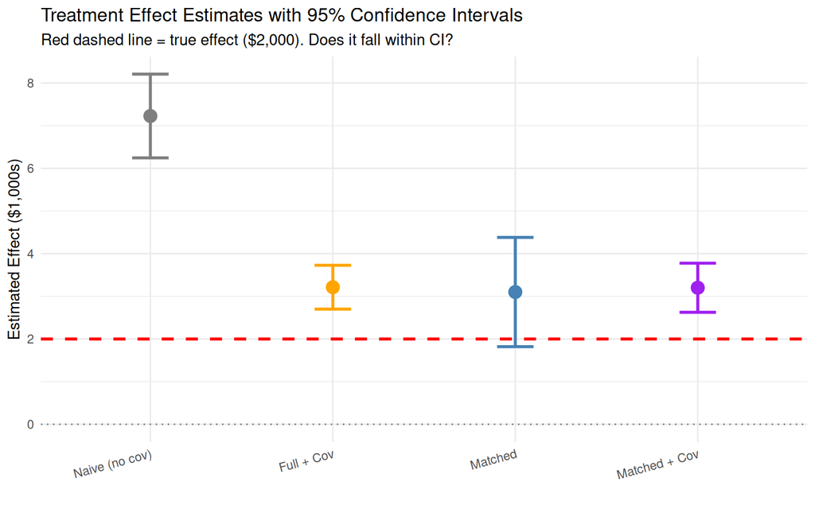

```r
ciData <- data.frame(
  method = factor(c("Naive (no cov)", "Full + Cov", "Matched", "Matched + Cov"),
                  levels = c("Naive (no cov)", "Full + Cov", "Matched", "Matched + Cov")),
  estimate = c(naiveEst, regLinearEst, matchedEst, matchedCovEst),
  ci_low = c(naive_ci[1], regLin_ci[1], matched_ci[1], matchedCov_ci[1]),
  ci_high = c(naive_ci[2], regLin_ci[2], matched_ci[2], matchedCov_ci[2])
)

ggplot(ciData, aes(x = method, y = estimate, color = method)) +
  geom_point(size = 4) +
  geom_errorbar(aes(ymin = ci_low, ymax = ci_high), width = 0.2, linewidth = 1) +
  geom_hline(yintercept = 2, linetype = "dashed", color = "red", linewidth = 1) +
  geom_hline(yintercept = 0, linetype = "dotted", color = "gray50") +
  scale_color_manual(values = c("Naive (no cov)" = "gray50", "Full + Cov" = "orange",
                                 "Matched" = "steelblue", "Matched + Cov" = "purple")) +
  labs(title = "Treatment Effect Estimates with 95% Confidence Intervals",
       subtitle = "Red dashed line = true effect ($2,000). Does it fall within CI?",
       x = "", y = "Estimated Effect ($1,000s)") +
  theme_minimal() +
  theme(legend.position = "none", axis.text.x = element_text(angle = 15, hjust = 1))
```

### Key Interpretation

1. **ALL methods find a statistically significant effect** (p < 0.05). We’d reject H₀: effect = 0 in all cases.
2. **BUT:** The true effect ($2,000) may NOT fall within the 95% CI! This shows that **statistical significance ≠ unbiased estimation**.
3. **Due to CONFOUNDING BIAS:**
   - Our estimates are BIASED (too high)
   - The confidence intervals are centered around the WRONG value
   - Even with tight standard errors, we’re precisely WRONG
4. **KEY LESSON:** Statistical significance tells us the effect is unlikely to be ZERO. It does NOT tell us our estimate is CORRECT or unbiased. Unobserved confounding creates bias that p-values cannot detect!

# Key Insights

## Comparing the Methods

The true salary model includes **NON-LINEAR** terms:

- prior_exp^2 (quadratic effect of experience)
- quant_skills x stem_background (interaction)

**Linear regression (Method 2)** assumes:

`salary = B0 + B1*ai_user + B2*prior_exp + B3*quant_skills + B4*stem_background`

This is **MISSPECIFIED** - it misses the non-linear effects!

**Matching (Method 3)** makes NO functional form assumptions. It simply compares AI users to similar non-users. Doesn’t require specifying the correct outcome model.

**REMAINING BIAS** comes from UNOBSERVED confounders: curiosity, tech_readiness, ai_aversion. Neither matching nor regression can fix this!

## Bottom Line

# Summary